# Real Estate

## Course-end Project 1

### Description

A banking institution requires actionable insights into mortgage-backed securities, geographic business investment, and real estate analysis. The mortgage bank would like to identify potential monthly mortgage expenses for each region based on monthly family income and rental of the real estate. A statistical model needs to be created to predict the potential demand in dollars amount of loan for each of the region in the USA. Also, there is a need to create a dashboard which would refresh periodically post data retrieval from the agencies. The dashboard must demonstrate relationships and trends for the key metrics as follows: number of loans, average rental income, monthly mortgage and owner’s cost, family income vs mortgage cost comparison across different regions. The metrics described here do not limit the dashboard to these few. Dataset Description

### Variables

#### Description

- Second mortgage Households with a second mortgage statistics
- Home equity Households with a home equity loan statistics
- Debt Households with any type of debt statistics
- Mortgage Costs Statistics regarding mortgage payments, home equity loans, utilities, and property taxes
- Home Owner Costs Sum of utilities, and property taxes statistics
- Gross Rent Contract rent plus the estimated average monthly cost of utility features
- High school Graduation High school graduation statistics
- Population Demographics Population demographics statistics
- Age Demographics Age demographic statistics
- Household Income Total income of people residing in the household
- Family Income Total income of people related to the householder

### Project Task: Week 1

#### Data Import and Preparation:

- Import data.
- Figure out the primary key and look for the requirement of indexing.
- Gauge the fill rate of the variables and devise plans for missing value treatment. Please explain explicitly the reason for the treatment chosen for each variable.

#### Exploratory Data Analysis (EDA):

- Perform debt analysis. You may take the following steps:
- Explore the top 2,500 locations where the percentage of households with a second mortgage is the highest and percent ownership is above 10 percent. Visualize using geo-map. You may keep the upper limit for the percent of households with a second mortgage to 50 percent

##### Use the following bad debt equation:

```
    Bad Debt = P (Second Mortgage ∩ Home Equity Loan)
    Bad Debt = second_mortgage + home_equity - home_equity_second_mortgage
    Create pie charts  to show overall debt and bad debt
```

- Create Box and whisker plot and analyze the distribution for 2nd mortgage, home equity, good debt, and bad debt for different cities
- Create a collated income distribution chart for family income, house hold income, and remaining income
- Perform EDA and come out with insights into population density and age. You may have to derive new fields (make sure to weight averages for accurate measurements):
- Use pop and ALand variables to create a new field called population density
- Use male_age_median, female_age_median, male_pop, and female_pop to create a new field called median age
- Visualize the findings using appropriate chart type
- Create bins for population into a new variable by selecting appropriate class interval so that the number of categories don’t exceed 5 for the ease of analysis.
- Analyze the married, separated, and divorced population for these population brackets
- Visualize using appropriate chart type
- Please detail your observations for rent as a percentage of income at an overall level, and for different states.
- Perform correlation analysis for all the relevant variables by creating a heatmap. Describe your findings.

### Project Task: Week 2

#### Data Pre-processing:

- The economic multivariate data has a significant number of measured variables. The goal is to find where the measured variables depend on a number of smaller unobserved common factors or latent variables.
- Each variable is assumed to be dependent upon a linear combination of the common factors, and the coefficients are known as loadings. Each measured variable also includes a component due to independent random variability, known as “specific variance” because it is specific to one variable. Obtain the common factors and then plot the loadings. Use factor analysis to find latent variables in our dataset and gain insight into the linear relationships in the data.

##### Following are the list of latent variables:

```
        * Highschool graduation rates

        * Median population age

        * Second mortgage statistics

        * Percent own

        * Bad debt expense
```

#### Data Modeling :

- Build a linear Regression model to predict the total monthly expenditure for home mortgages loan.

  ```
   Please refer deplotment_RE.xlsx. Column hc_mortgage_mean is predicted variable. This is the mean monthly mortgage and owner costs of specified geographical location.

   Note: Exclude loans from prediction model which have NaN (Not a Number) values for hc_mortgage_mean.

   a) Run a model at a Nation level. If the accuracy levels and R square are not satisfactory proceed to below step.

   b) Run another model at State level. There are 52 states in USA.

   c) Keep below considerations while building a linear regression model:
  ```

- Variables should have significant impact on predicting Monthly mortgage and owner costs
- Utilize all predictor variable to start with initial hypothesis
- R square of 60 percent and above should be achieved
- Ensure Multi-collinearity does not exist in dependent variables
- Test if predicted variable is normally distributed

#### Data Reporting:

- Create a dashboard in tableau by choosing appropriate chart types and metrics useful for the business. The dashboard must entail the following:
- Box plot of distribution of average rent by type of place (village, urban, town, etc.).
- Pie charts to show overall debt and bad debt.
- Explore the top 2,500 locations where the percentage of households with a second mortgage is the highest and percent ownership is above 10 percent. Visualize using geo-map.
- Heat map for correlation matrix.
- Pie chart to show the population distribution across different types of places (village, urban, town etc.).

# Data Import and Preparation:

## Question 1

### Import data.

```python
! pip install numpy pandas scikit-learn matplotlib seaborn plotly dash factor-analyzer
```

```python
import numpy as np
import pandas as pd
import matplotlib.pyplot as plt
import seaborn as sns
import plotly.express as px
from plotly.subplots import make_subplots
import plotly.graph_objects as go
import plotly.figure_factory as ff
from dash import Dash, html, dcc, callback, Output, Input
import geopandas as gpd
from factor_analyzer import FactorAnalyzer
from scipy import stats
import warnings
```

```python
warnings.filterwarnings('ignore')
pd.set_option('display.max_rows', None)
sns.set_style('dark')
pd.set_option('display.max_columns', None)
sns.set(rc={'axes.facecolor':'black', 'figure.facecolor':'darkgrey'})
```

```python
# Imports from Sklearn and other modelling packages
from sklearn.impute import KNNImputer
from sklearn.preprocessing import LabelEncoder
from sklearn.preprocessing import StandardScaler
from sklearn.linear_model import LinearRegression
from sklearn.metrics import r2_score
```

```python
# Loading Data
df_train = pd.read_csv('train.csv'); print(df_train.shape)
df_test = pd.read_csv('test.csv'); print(df_test.shape)

#This flag will help us split the data back later
df_train['split']= 'Train'
df_test['split']= 'Test'


df = pd.concat([df_train, df_test], axis=0); print(df.shape)

df.head()
```

```
(27321, 80)
(11709, 80)
(39030, 81)
```

|  | UID | BLOCKID | SUMLEVEL | COUNTYID | STATEID | state | state_ab | city | place | type | primary | zip_code | area_code | lat | lng | ALand | AWater | pop | male_pop | female_pop | rent_mean | rent_median | rent_stdev | rent_sample_weight | rent_samples | rent_gt_10 | rent_gt_15 | rent_gt_20 | rent_gt_25 | … |
| --- | --- | --- | --- | --- | --- | --- | --- | --- | --- | --- | --- | --- | --- | --- | --- | --- | --- | --- | --- | --- | --- | --- | --- | --- | --- | --- | --- | --- | --- | --- |
| 0 | 267822 | NaN | 140 | 53 | 36 | New York | NY | Hamilton | Hamilton | City | tract | 13346 | 315 | 42.840812 | -75.501524 | 202183361.0 | 1699120 | 5230 | 2612 | 2618 | 769.38638 | 784.0 | 232.63967 | 272.34441 | 362.0 | 0.86761 | 0.79155 | 0.59155 | 0.45634 | … |
| 1 | 246444 | NaN | 140 | 141 | 18 | Indiana | IN | South Bend | Roseland | City | tract | 46616 | 574 | 41.701441 | -86.266614 | 1560828.0 | 100363 | 2633 | 1349 | 1284 | 804.87924 | 848.0 | 253.46747 | 312.58622 | 513.0 | 0.97410 | 0.93227 | 0.69920 | 0.69920 | … |
| 2 | 245683 | NaN | 140 | 63 | 18 | Indiana | IN | Danville | Danville | City | tract | 46122 | 317 | 39.792202 | -86.515246 | 69561595.0 | 284193 | 6881 | 3643 | 3238 | 742.77365 | 703.0 | 323.39011 | 291.85520 | 378.0 | 0.95238 | 0.88624 | 0.79630 | 0.66667 | … |
| 3 | 279653 | NaN | 140 | 127 | 72 | Puerto Rico | PR | San Juan | Guaynabo | Urban | tract | 927 | 787 | 18.396103 | -66.104169 | 1105793.0 | 0 | 2700 | 1141 | 1559 | 803.42018 | 782.0 | 297.39258 | 259.30316 | 368.0 | 0.94693 | 0.87151 | 0.69832 | 0.61732 | … |
| 4 | 247218 | NaN | 140 | 161 | 20 | Kansas | KS | Manhattan | Manhattan City | City | tract | 66502 | 785 | 39.195573 | -96.569366 | 2554403.0 | 0 | 5637 | 2586 | 3051 | 938.56493 | 881.0 | 392.44096 | 1005.42886 | 1704.0 | 0.99286 | 0.98247 | 0.91688 | 0.84740 | … |

## Question 2

### Figure out the primary key and look for the requirement of indexing.

```python
df.info()
```

```
<class 'pandas.core.frame.DataFrame'>
Index: 39030 entries, 0 to 11708
Data columns (total 81 columns):
 #   Column                       Non-Null Count  Dtype
---  ------                       --------------  -----
 0   UID                          39030 non-null  int64
 1   BLOCKID                      0 non-null      float64
 2   SUMLEVEL                     39030 non-null  int64
 3   COUNTYID                     39030 non-null  int64
 4   STATEID                      39030 non-null  int64
 5   state                        39030 non-null  object
 6   state_ab                     39030 non-null  object
 7   city                         39030 non-null  object
 8   place                        39030 non-null  object
 9   type                         39030 non-null  object
```

[output cut: 73 more lines]

- Changing the naems of columns to lower-case

```python
df.columns = df.columns.str.lower()
```

```python
df.describe().transpose()
```

|  | count | mean | std | min | 25% | 50% | 75% | max |
| --- | --- | --- | --- | --- | --- | --- | --- | --- |
| uid | 39030.0 | 2.573899e+05 | 2.138060e+04 | 220336.000000 | 2.388172e+05 | 2.573805e+05 | 2.759708e+05 | 2.943340e+05 |
| blockid | 0.0 | NaN | NaN | NaN | NaN | NaN | NaN | NaN |
| sumlevel | 39030.0 | 1.400000e+02 | 0.000000e+00 | 140.000000 | 1.400000e+02 | 1.400000e+02 | 1.400000e+02 | 1.400000e+02 |
| countyid | 39030.0 | 8.566569e+01 | 9.862420e+01 | 1.000000 | 2.900000e+01 | 6.300000e+01 | 1.090000e+02 | 8.400000e+02 |
| stateid | 39030.0 | 2.833702e+01 | 1.645755e+01 | 1.000000 | 1.300000e+01 | 2.800000e+01 | 4.200000e+01 | 7.200000e+01 |
| zip_code | 39030.0 | 5.009443e+04 | 2.962301e+04 | 601.000000 | 2.626100e+04 | 4.763750e+04 | 7.732000e+04 | 9.992900e+04 |
| area_code | 39030.0 | 5.956349e+02 | 2.323714e+02 | 201.000000 | 4.050000e+02 | 6.140000e+02 | 8.010000e+02 | 9.890000e+02 |
| lat | 39030.0 | 3.747782e+01 | 5.599713e+00 | 17.929085 | 3.390548e+01 | 3.871221e+01 | 4.132777e+01 | 6.707402e+01 |
| lng | 39030.0 | -9.130394e+01 | 1.636285e+01 | -166.770979 | -9.781644e+01 | -8.658708e+01 | -7.976499e+01 | -6.537933e+01 |
| aland | 39030.0 | 1.235224e+08 | 1.146022e+09 | 8299.000000 | 1.777882e+06 | 4.854619e+06 | 3.320334e+07 | 1.039510e+11 |
| awater | 39030.0 | 6.112049e+06 | 2.010698e+08 | 0.000000 | 0.000000e+00 | 2.595650e+04 | 5.132392e+05 | 2.453228e+10 |
| pop | 39030.0 | 4.331385e+03 | 2.155202e+03 | 0.000000 | 2.899000e+03 | 4.065000e+03 | 5.442000e+03 | 5.381200e+04 |
| male_pop | 39030.0 | 2.132501e+03 | 1.106520e+03 | 0.000000 | 1.412000e+03 | 1.988000e+03 | 2.673000e+03 | 2.796200e+04 |
| female_pop | 39030.0 | 2.198884e+03 | 1.097316e+03 | 0.000000 | 1.463000e+03 | 2.067000e+03 | 2.773000e+03 | 2.725000e+04 |
| rent_mean | 38568.0 | 1.054833e+03 | 4.365636e+02 | 117.150000 | 7.426814e+02 | 9.529741e+02 | 1.259885e+03 | 3.962342e+03 |
| rent_median | 38568.0 | 1.007476e+03 | 4.431000e+02 | 104.000000 | 7.030000e+02 | 8.970000e+02 | 1.197000e+03 | 3.972000e+03 |
| rent_stdev | 38568.0 | 3.943633e+02 | 1.877907e+02 | 18.257420 | 2.632678e+02 | 3.471726e+02 | 4.756280e+02 | 1.720719e+03 |
| rent_sample_weight | 38568.0 | 2.985383e+02 | 2.749905e+02 | 0.343000 | 1.023907e+02 | 2.222738e+02 | 4.120453e+02 | 4.112122e+03 |
| rent_samples | 38568.0 | 5.526431e+02 | 4.655351e+02 | 3.000000 | 2.230000e+02 | 4.290000e+02 | 7.490000e+02 | 7.634000e+03 |
| rent_gt_10 | 38567.0 | 9.577213e-01 | 6.331078e-02 | 0.000000 | 9.405900e-01 | 9.770500e-01 | 1.000000e+00 | 1.000000e+00 |
| rent_gt_15 | 38567.0 | 8.673243e-01 | 1.090979e-01 | 0.000000 | 8.197400e-01 | 8.885000e-01 | 9.403100e-01 | 1.000000e+00 |
| rent_gt_20 | 38567.0 | 7.403840e-01 | 1.434207e-01 | 0.000000 | 6.630550e-01 | 7.598800e-01 | 8.380800e-01 | 1.000000e+00 |
| rent_gt_25 | 38567.0 | 6.133925e-01 | 1.606805e-01 | 0.000000 | 5.171350e-01 | 6.256700e-01 | 7.234200e-01 | 1.000000e+00 |
| rent_gt_30 | 38567.0 | 5.003519e-01 | 1.645326e-01 | 0.000000 | 3.966900e-01 | 5.044700e-01 | 6.095150e-01 | 1.000000e+00 |
| rent_gt_35 | 38567.0 | 4.116023e-01 | 1.605353e-01 | 0.000000 | 3.073900e-01 | 4.099400e-01 | 5.157350e-01 | 1.000000e+00 |
| rent_gt_40 | 38567.0 | 3.458975e-01 | 1.534465e-01 | 0.000000 | 2.429400e-01 | 3.395000e-01 | 4.420000e-01 | 1.000000e+00 |
| rent_gt_50 | 38567.0 | 2.547799e-01 | 1.377162e-01 | 0.000000 | 1.606400e-01 | 2.431500e-01 | 3.370750e-01 | 1.000000e+00 |
| universe_samples | 39030.0 | 5.786274e+02 | 4.695183e+02 | 0.000000 | 2.510000e+02 | 4.590000e+02 | 7.770000e+02 | 7.634000e+03 |
| used_samples | 39030.0 | 5.327799e+02 | 4.544985e+02 | 0.000000 | 2.110000e+02 | 4.130000e+02 | 7.250000e+02 | 7.336000e+03 |
| hi_mean | 38640.0 | 7.035984e+04 | 3.030312e+04 | 4999.846690 | 4.905325e+04 | 6.396553e+04 | 8.570023e+04 | 2.971429e+05 |
| hi_median | 38640.0 | 5.751498e+04 | 2.928903e+04 | 4790.000000 | 3.731525e+04 | 5.118800e+04 | 7.067925e+04 | 2.968970e+05 |
| hi_stdev | 38640.0 | 5.434974e+04 | 1.767257e+04 | 1825.741860 | 4.197626e+04 | 5.213996e+04 | 6.517940e+04 | 1.359026e+05 |
| hi_sample_weight | 38640.0 | 9.270302e+02 | 4.544973e+02 | 0.114260 | 6.033096e+02 | 8.672207e+02 | 1.184152e+03 | 1.093198e+04 |
| hi_samples | 38640.0 | 1.612883e+03 | 7.500159e+02 | 3.000000 | 1.099000e+03 | 1.522000e+03 | 2.022000e+03 | 2.039500e+04 |
| family_mean | 38596.0 | 7.889682e+04 | 3.156500e+04 | 5374.842520 | 5.662406e+04 | 7.285496e+04 | 9.591450e+04 | 2.428571e+05 |
| family_median | 38596.0 | 6.921084e+04 | 3.367063e+04 | 5278.000000 | 4.601725e+04 | 6.226850e+04 | 8.460075e+04 | 2.427200e+05 |
| family_stdev | 38596.0 | 5.063234e+04 | 1.427344e+04 | 1825.741860 | 4.074870e+04 | 4.958999e+04 | 6.039576e+04 | 1.112567e+05 |
| family_sample_weight | 38596.0 | 5.356586e+02 | 2.901442e+02 | 0.199960 | 3.332809e+02 | 4.924642e+02 | 6.868784e+02 | 6.904497e+03 |
| family_samples | 38596.0 | 1.066489e+03 | 5.579105e+02 | 3.000000 | 6.887500e+02 | 9.890000e+02 | 1.352000e+03 | 1.493800e+04 |
| hc_mortgage_mean | 38189.0 | 1.631830e+03 | 6.266921e+02 | 234.650000 | 1.156408e+03 | 1.461484e+03 | 1.985853e+03 | 4.462342e+03 |
| hc_mortgage_median | 38189.0 | 1.553907e+03 | 6.562238e+02 | 237.000000 | 1.067000e+03 | 1.372000e+03 | 1.879000e+03 | 4.472000e+03 |
| hc_mortgage_stdev | 38189.0 | 6.223144e+02 | 2.388920e+02 | 36.514840 | 4.395353e+02 | 5.884327e+02 | 7.879708e+02 | 1.814114e+03 |
| hc_mortgage_sample_weight | 38189.0 | 2.880717e+02 | 1.958908e+02 | 0.198400 | 1.478149e+02 | 2.540932e+02 | 3.872603e+02 | 4.226744e+03 |
| hc_mortgage_samples | 38189.0 | 6.709076e+02 | 4.635394e+02 | 1.000000 | 3.460000e+02 | 5.910000e+02 | 8.990000e+02 | 1.167000e+04 |
| hc_mean | 38140.0 | 5.400576e+02 | 2.228372e+02 | 53.594610 | 3.885522e+02 | 4.778551e+02 | 6.310456e+02 | 1.700179e+03 |
| hc_median | 38140.0 | 5.129899e+02 | 2.332398e+02 | 53.000000 | 3.600000e+02 | 4.480000e+02 | 5.990000e+02 | 1.702000e+03 |
| hc_stdev | 38140.0 | 2.184086e+02 | 9.195354e+01 | 18.257420 | 1.538986e+02 | 1.985915e+02 | 2.662663e+02 | 8.209686e+02 |
| hc_samples | 38140.0 | 3.701282e+02 | 2.504009e+02 | 2.000000 | 1.920000e+02 | 3.270000e+02 | 5.010000e+02 | 1.133000e+04 |
| hc_sample_weight | 38140.0 | 2.548620e+02 | 1.900167e+02 | 0.491230 | 1.202828e+02 | 2.126803e+02 | 3.432932e+02 | 7.107065e+03 |
| home_equity_second_mortgage | 38353.0 | 2.572316e-02 | 3.108756e-02 | 0.000000 | 5.020000e-03 | 1.859000e-02 | 3.704000e-02 | 1.000000e+00 |
| second_mortgage | 38353.0 | 3.001914e-02 | 3.398802e-02 | 0.000000 | 7.720000e-03 | 2.252000e-02 | 4.285000e-02 | 1.000000e+00 |
| home_equity | 38353.0 | 1.010637e-01 | 6.963801e-02 | 0.000000 | 4.938000e-02 | 9.461000e-02 | 1.436000e-01 | 1.000000e+00 |
| debt | 38353.0 | 6.299163e-01 | 1.566799e-01 | 0.000000 | 5.392900e-01 | 6.487900e-01 | 7.385900e-01 | 1.000000e+00 |
| second_mortgage_cdf | 38353.0 | 4.677382e-01 | 2.955378e-01 | 0.000000 | 2.481300e-01 | 4.190400e-01 | 5.538100e-01 | 1.000000e+00 |
| home_equity_cdf | 38353.0 | 4.768957e-01 | 2.564298e-01 | 0.000000 | 2.648800e-01 | 4.656200e-01 | 6.778500e-01 | 1.000000e+00 |
| debt_cdf | 38353.0 | 4.979522e-01 | 2.643914e-01 | 0.000000 | 2.788400e-01 | 4.907200e-01 | 7.173900e-01 | 1.000000e+00 |
| hs_degree | 38755.0 | 8.576950e-01 | 1.130291e-01 | 0.000000 | 8.063650e-01 | 8.883700e-01 | 9.398050e-01 | 1.000000e+00 |
| hs_degree_male | 38741.0 | 8.512397e-01 | 1.213130e-01 | 0.000000 | 7.934900e-01 | 8.830500e-01 | 9.408400e-01 | 1.000000e+00 |
| hs_degree_female | 38702.0 | 8.643533e-01 | 1.125550e-01 | 0.000000 | 8.168025e-01 | 8.953050e-01 | 9.447600e-01 | 1.000000e+00 |
| male_age_mean | 38757.0 | 3.828283e+01 | 5.596338e+00 | 12.145830 | 3.499516e+01 | 3.829111e+01 | 4.134406e+01 | 8.335833e+01 |
| male_age_median | 38757.0 | 3.800188e+01 | 7.851792e+00 | 9.750000 | 3.275000e+01 | 3.783333e+01 | 4.283333e+01 | 8.333333e+01 |
| male_age_stdev | 38757.0 | 2.147981e+01 | 2.553394e+00 | 0.737110 | 2.055694e+01 | 2.190030e+01 | 2.295085e+01 | 3.106095e+01 |
| male_age_sample_weight | 38757.0 | 5.377034e+02 | 3.079646e+02 | 0.745760 | 3.491365e+02 | 4.937908e+02 | 6.687151e+02 | 1.201707e+04 |
| male_age_samples | 38757.0 | 2.147522e+03 | 1.095788e+03 | 3.000000 | 1.425000e+03 | 1.995000e+03 | 2.679000e+03 | 2.796200e+04 |
| female_age_mean | 38728.0 | 4.025749e+01 | 5.876502e+00 | 15.360240 | 3.683268e+01 | 4.032055e+01 | 4.354850e+01 | 9.010794e+01 |
| female_age_median | 38728.0 | 4.028816e+01 | 8.019936e+00 | 12.833330 | 3.483333e+01 | 4.050000e+01 | 4.533333e+01 | 9.016667e+01 |
| female_age_stdev | 38728.0 | 2.216957e+01 | 2.544665e+00 | 0.556780 | 2.130053e+01 | 2.250221e+01 | 2.356625e+01 | 3.024127e+01 |
| female_age_sample_weight | 38728.0 | 5.460894e+02 | 2.827939e+02 | 0.251910 | 3.579785e+02 | 5.049821e+02 | 6.823097e+02 | 6.197995e+03 |
| female_age_samples | 38728.0 | 2.216031e+03 | 1.084201e+03 | 2.000000 | 1.480000e+03 | 2.078000e+03 | 2.781000e+03 | 2.725000e+04 |
| pct_own | 38640.0 | 6.385631e-01 | 2.283459e-01 | 0.000000 | 5.003375e-01 | 6.896700e-01 | 8.167825e-01 | 1.000000e+00 |
| married | 38755.0 | 5.074999e-01 | 1.377443e-01 | 0.000000 | 4.242950e-01 | 5.262100e-01 | 6.057150e-01 | 1.000000e+00 |
| married_snp | 38755.0 | 4.766375e-02 | 3.795871e-02 | 0.000000 | 2.084000e-02 | 3.879000e-02 | 6.518000e-02 | 7.142900e-01 |
| separated | 38755.0 | 1.916585e-02 | 2.098770e-02 | 0.000000 | 4.530000e-03 | 1.358000e-02 | 2.765000e-02 | 7.142900e-01 |
| divorced | 38755.0 | 9.993071e-02 | 4.889849e-02 | 0.000000 | 6.542000e-02 | 9.491000e-02 | 1.287900e-01 | 1.000000e+00 |

```python
df['sumlevel'].unique()
```

```
array([140], dtype=int64)
```

```python
df['blockid'].unique()
```

```
array([nan])
```

- Dropping the BLOCKID column as there are no values in the feature

```python
df.drop(['blockid', 'sumlevel'], axis = 1, inplace=True)
df.head()
```

|  | uid | countyid | stateid | state | state_ab | city | place | type | primary | zip_code | area_code | lat | lng | aland | awater | pop | male_pop | female_pop | rent_mean | rent_median | rent_stdev | rent_sample_weight | rent_samples | rent_gt_10 | rent_gt_15 | rent_gt_20 | rent_gt_25 | rent_gt_30 | rent_gt_35 | … |
| --- | --- | --- | --- | --- | --- | --- | --- | --- | --- | --- | --- | --- | --- | --- | --- | --- | --- | --- | --- | --- | --- | --- | --- | --- | --- | --- | --- | --- | --- | --- |
| 0 | 267822 | 53 | 36 | New York | NY | Hamilton | Hamilton | City | tract | 13346 | 315 | 42.840812 | -75.501524 | 202183361.0 | 1699120 | 5230 | 2612 | 2618 | 769.38638 | 784.0 | 232.63967 | 272.34441 | 362.0 | 0.86761 | 0.79155 | 0.59155 | 0.45634 | 0.42817 | 0.18592 | … |
| 1 | 246444 | 141 | 18 | Indiana | IN | South Bend | Roseland | City | tract | 46616 | 574 | 41.701441 | -86.266614 | 1560828.0 | 100363 | 2633 | 1349 | 1284 | 804.87924 | 848.0 | 253.46747 | 312.58622 | 513.0 | 0.97410 | 0.93227 | 0.69920 | 0.69920 | 0.55179 | 0.41235 | … |
| 2 | 245683 | 63 | 18 | Indiana | IN | Danville | Danville | City | tract | 46122 | 317 | 39.792202 | -86.515246 | 69561595.0 | 284193 | 6881 | 3643 | 3238 | 742.77365 | 703.0 | 323.39011 | 291.85520 | 378.0 | 0.95238 | 0.88624 | 0.79630 | 0.66667 | 0.39153 | 0.39153 | … |
| 3 | 279653 | 127 | 72 | Puerto Rico | PR | San Juan | Guaynabo | Urban | tract | 927 | 787 | 18.396103 | -66.104169 | 1105793.0 | 0 | 2700 | 1141 | 1559 | 803.42018 | 782.0 | 297.39258 | 259.30316 | 368.0 | 0.94693 | 0.87151 | 0.69832 | 0.61732 | 0.51397 | 0.46927 | … |
| 4 | 247218 | 161 | 20 | Kansas | KS | Manhattan | Manhattan City | City | tract | 66502 | 785 | 39.195573 | -96.569366 | 2554403.0 | 0 | 5637 | 2586 | 3051 | 938.56493 | 881.0 | 392.44096 | 1005.42886 | 1704.0 | 0.99286 | 0.98247 | 0.91688 | 0.84740 | 0.78247 | 0.60974 | … |

```python
print(df.duplicated().sum())
df.drop_duplicates(inplace= True)
print(df.duplicated().sum())
```

```
192
0
```

- Checking the UID for its suitablity of becoming the index

```python
df.info()
```

```
<class 'pandas.core.frame.DataFrame'>
Index: 38838 entries, 0 to 11708
Data columns (total 79 columns):
 #   Column                       Non-Null Count  Dtype
---  ------                       --------------  -----
 0   uid                          38838 non-null  int64
 1   countyid                     38838 non-null  int64
 2   stateid                      38838 non-null  int64
 3   state                        38838 non-null  object
 4   state_ab                     38838 non-null  object
 5   city                         38838 non-null  object
 6   place                        38838 non-null  object
 7   type                         38838 non-null  object
 8   primary                      38838 non-null  object
 9   zip_code                     38838 non-null  int64
```

[output cut: 71 more lines]

```python
df.drop_duplicates('uid', inplace= True)
df.set_index('uid', inplace=True)
df.sort_index(inplace=True)
df.head(10)
```

| uid | countyid | stateid | state | state_ab | city | place | type | primary | zip_code | area_code | lat | lng | aland | awater | pop | male_pop | female_pop | rent_mean | rent_median | rent_stdev | rent_sample_weight | rent_samples | rent_gt_10 | rent_gt_15 | rent_gt_20 | rent_gt_25 | rent_gt_30 | rent_gt_35 | rent_gt_40 | … |
| --- | --- | --- | --- | --- | --- | --- | --- | --- | --- | --- | --- | --- | --- | --- | --- | --- | --- | --- | --- | --- | --- | --- | --- | --- | --- | --- | --- | --- | --- | --- |
| 220336 | 16 | 2 | Alaska | AK | Unalaska | Unalaska City | City | tract | 99685 | 907 | 53.621091 | -166.770979 | 2.823180e+09 | 3101986247 | 4619 | 2725 | 1894 | 1366.24657 | 1405.0 | 650.16380 | 131.50967 | 372.0 | 0.85676 | 0.65676 | 0.47838 | 0.35405 | 0.28108 | 0.21081 | 0.15135 | … |
| 220342 | 20 | 2 | Alaska | AK | Eagle River | Anchorage | City | tract | 99577 | 907 | 61.174250 | -149.284329 | 5.092349e+08 | 1859309 | 3727 | 1780 | 1947 | 2347.69441 | 2351.0 | 382.73576 | 4.32064 | 44.0 | 0.79545 | 0.56818 | 0.56818 | 0.45455 | 0.20455 | 0.20455 | 0.20455 | … |
| 220343 | 20 | 2 | Alaska | AK | Jber | Anchorage | City | tract | 99505 | 907 | 61.284745 | -149.653973 | 2.705930e+08 | 66534601 | 8736 | 5166 | 3570 | 2071.30766 | 2089.0 | 442.89099 | 195.07816 | 1749.0 | 0.99469 | 0.97403 | 0.92680 | 0.89020 | 0.73022 | 0.62574 | 0.54368 | … |
| 220345 | 20 | 2 | Alaska | AK | Anchorage | Point Mackenzie | City | tract | 99501 | 907 | 61.229560 | -149.893037 | 2.371512e+06 | 9966854 | 1941 | 892 | 1049 | 943.79086 | 914.0 | 308.34101 | 396.51652 | 720.0 | 0.97046 | 0.81435 | 0.67651 | 0.58509 | 0.39381 | 0.32208 | 0.27286 | … |
| 220347 | 20 | 2 | Alaska | AK | Anchorage | Anchorage | City | tract | 99504 | 907 | 61.217082 | -149.767214 | 1.979230e+06 | 0 | 5981 | 3076 | 2905 | 1372.84472 | 1222.0 | 541.82102 | 251.53249 | 878.0 | 0.97836 | 0.90319 | 0.80068 | 0.66856 | 0.45900 | 0.34738 | 0.24829 | … |
| 220348 | 20 | 2 | Alaska | AK | Anchorage | Anchorage | City | tract | 99504 | 907 | 61.217507 | -149.744426 | 2.089774e+06 | 0 | 5476 | 2916 | 2560 | 1351.27532 | 1353.0 | 416.08723 | 259.25649 | 963.0 | 0.97701 | 0.96343 | 0.80460 | 0.64054 | 0.51515 | 0.35319 | 0.19749 | … |
| 220349 | 20 | 2 | Alaska | AK | Anchorage | Anchorage | City | tract | 99504 | 907 | 61.223372 | -149.723327 | 2.936374e+06 | 0 | 5893 | 3037 | 2856 | 1022.91322 | 1076.0 | 504.56448 | 529.85586 | 1081.0 | 0.97040 | 0.90564 | 0.90564 | 0.77058 | 0.64477 | 0.48104 | 0.35338 | … |
| 220350 | 20 | 2 | Alaska | AK | Anchorage | Point Mackenzie | City | tract | 99508 | 907 | 61.216701 | -149.792744 | 2.494426e+06 | 0 | 7481 | 3766 | 3715 | 1101.88070 | 1034.0 | 440.95777 | 459.72485 | 1053.0 | 0.94397 | 0.94397 | 0.79202 | 0.61349 | 0.47198 | 0.47198 | 0.43590 | … |
| 220352 | 20 | 2 | Alaska | AK | Anchorage | Point Mackenzie | City | tract | 99508 | 907 | 61.215067 | -149.836271 | 4.467475e+06 | 0 | 5501 | 3139 | 2362 | 884.61089 | 924.0 | 365.64048 | 564.66795 | 1003.0 | 0.91242 | 0.77291 | 0.64460 | 0.52953 | 0.46130 | 0.37882 | 0.30346 | … |
| 220353 | 20 | 2 | Alaska | AK | Anchorage | Point Mackenzie | City | tract | 99501 | 907 | 61.204383 | -149.852526 | 1.146156e+06 | 0 | 3225 | 1565 | 1660 | 991.76412 | 1068.0 | 440.74246 | 417.58346 | 843.0 | 0.97509 | 0.89324 | 0.67378 | 0.64294 | 0.47450 | 0.39739 | 0.25979 | … |

## Question 3

### Gauge the fill rate of the variables and devise plans for missing value treatment. Please explain explicitly the reason for the treatment chosen for each variable.

```python
print(">>>Total number of columns with null values\n...", end = ' ')
print((df.isnull().sum() != 0).sum())
print(">>>Total number of Numerical columns with null values\n...", end = ' ')
print((df.select_dtypes('number').isnull().sum() != 0).sum())
print(">>>Total number of Object columns with null values\n...", end = ' ')
print((df.select_dtypes('object').isnull().sum() != 0).sum())
print(">>>Total number of missing values\n...", end = ' ')
print(df.isnull().sum().sum())
```

```
>>>Total number of columns with null values
... 58
>>>Total number of Numerical columns with null values
... 58
>>>Total number of Object columns with null values
... 0
>>>Total number of missing values
... 20328
```

- As the number of missing values are bigger, we will go *KNN Imputation* method

```python
imputer = KNNImputer(n_neighbors= 1)
# Getting the columns of dataframe which have null values and imputing the values
for i in df.columns:
    if df[i].isna().sum() != 0:
        df[i] = imputer.fit_transform(pd.DataFrame(df[i]))


print(">>>Total number of columns with null values\n...", end = ' ')
print((df.isnull().sum() != 0).sum())
print(">>>Total number of Numerical columns with null values\n...", end = ' ')
print((df.select_dtypes('number').isnull().sum() != 0).sum())
print(">>>Total number of Object columns with null values\n...", end = ' ')
print((df.select_dtypes('object').isnull().sum() != 0).sum())
print(">>>Total number of missing values\n...", end = ' ')
print(df.isnull().sum().sum())
print(">>>Shape of dataframe\n...", end = ' ')
print(df.shape)
```

```
>>>Total number of columns with null values
... 0
>>>Total number of Numerical columns with null values
... 0
>>>Total number of Object columns with null values
... 0
>>>Total number of missing values
... 0
>>>Shape of dataframe
... (38715, 78)
```

# Exploratory Data Analysis (EDA):

```python
feature_list = df.select_dtypes('number').columns
```

```python
l = len(feature_list)

row = l // 3 +1

fig = make_subplots(cols = 3,
                    rows = row,
                    subplot_titles=[f'<i>{i.title()}</i>' for i in feature_list])
for i in range(l):
    fig.add_trace(go.Histogram(x = df[feature_list[i]]),
                  col = i //  row +1,
                  row = i % row +1)

fig.update_layout(height = 2900,
                width = 900,
                title_text = '<b>Feature Distribution',
                template = 'plotly_dark',
                title_x = 0.5,
                showlegend=False)


fig.show()
```

## Question 4

### Explore the top 2,500 locations where the percentage of households with a second mortgage is the highest and percent ownership is above 10 percent. Visualize using geo-map. You may keep the upper limit for the percent of households with a second mortgage to 50 percent

```python
df_debt = df.sort_values(by = 'second_mortgage', ascending=False)
df_debt = df_debt[df_debt['pct_own']>0.1].iloc[0:2500,]
df_debt.shape
```

```
(2500, 78)
```

```python
df_by_city_2500 = df_debt.select_dtypes('number').groupby(df['city']).mean()

debt_scatter = px.scatter_geo(data_frame=df_by_city_2500,
               lat = 'lat',
               lon= 'lng',
               color = 'debt',
               hover_name=df_by_city_2500.index,
               height = 700,
               width = 1000,
               template = 'plotly_dark',
               color_continuous_scale='tealrose',
               title = '<b>Debt Distribution in top 2500 Cities</b>',
               scope = 'usa')


debt_scatter.show()
```

```python
df_by_city = df.select_dtypes('number').groupby(df['city']).mean()

debt_scatter = px.scatter_geo(data_frame=df_by_city,
               lat = 'lat',
               lon= 'lng',
               color = 'debt',
               hover_name=df_by_city.index,
               height = 700,
               width = 1000,
               template = 'plotly_dark',
               title = '<b>Debt Distribution in All Locations</b>',
               color_continuous_scale='tealrose',
               scope = 'usa')
debt_scatter.show()
```

```python
df_by_state = df.groupby('state').sum().sort_values(by = 'debt', ascending=False)

debt_scatter = px.bar(data_frame=df_by_state,
                      y = 'debt',
               color = 'debt',
               hover_name=df_by_state.index,
               title = '<b>Debt Distribution by sum in all States</b>',
               template = 'plotly_dark')
debt_scatter.show()
```

#### Use the following bad debt equation:

```
     Bad Debt = P (Second Mortgage ∩ Home Equity Loan)
     Bad Debt = second_mortgage + home_equity - home_equity_second_mortgage
     Create pie charts  to show overall debt and bad debt
```

```python
df['bad_debt'] = df['second_mortgage'] + df['home_equity'] - df['home_equity_second_mortgage']

df.head()
```

| uid | countyid | stateid | state | state_ab | city | place | type | primary | zip_code | area_code | lat | lng | aland | awater | pop | male_pop | female_pop | rent_mean | rent_median | rent_stdev | rent_sample_weight | rent_samples | rent_gt_10 | rent_gt_15 | rent_gt_20 | rent_gt_25 | rent_gt_30 | rent_gt_35 | rent_gt_40 | … |
| --- | --- | --- | --- | --- | --- | --- | --- | --- | --- | --- | --- | --- | --- | --- | --- | --- | --- | --- | --- | --- | --- | --- | --- | --- | --- | --- | --- | --- | --- | --- |
| 220336 | 16 | 2 | Alaska | AK | Unalaska | Unalaska City | City | tract | 99685 | 907 | 53.621091 | -166.770979 | 2.823180e+09 | 3101986247 | 4619 | 2725 | 1894 | 1366.24657 | 1405.0 | 650.16380 | 131.50967 | 372.0 | 0.85676 | 0.65676 | 0.47838 | 0.35405 | 0.28108 | 0.21081 | 0.15135 | … |
| 220342 | 20 | 2 | Alaska | AK | Eagle River | Anchorage | City | tract | 99577 | 907 | 61.174250 | -149.284329 | 5.092349e+08 | 1859309 | 3727 | 1780 | 1947 | 2347.69441 | 2351.0 | 382.73576 | 4.32064 | 44.0 | 0.79545 | 0.56818 | 0.56818 | 0.45455 | 0.20455 | 0.20455 | 0.20455 | … |
| 220343 | 20 | 2 | Alaska | AK | Jber | Anchorage | City | tract | 99505 | 907 | 61.284745 | -149.653973 | 2.705930e+08 | 66534601 | 8736 | 5166 | 3570 | 2071.30766 | 2089.0 | 442.89099 | 195.07816 | 1749.0 | 0.99469 | 0.97403 | 0.92680 | 0.89020 | 0.73022 | 0.62574 | 0.54368 | … |
| 220345 | 20 | 2 | Alaska | AK | Anchorage | Point Mackenzie | City | tract | 99501 | 907 | 61.229560 | -149.893037 | 2.371512e+06 | 9966854 | 1941 | 892 | 1049 | 943.79086 | 914.0 | 308.34101 | 396.51652 | 720.0 | 0.97046 | 0.81435 | 0.67651 | 0.58509 | 0.39381 | 0.32208 | 0.27286 | … |
| 220347 | 20 | 2 | Alaska | AK | Anchorage | Anchorage | City | tract | 99504 | 907 | 61.217082 | -149.767214 | 1.979230e+06 | 0 | 5981 | 3076 | 2905 | 1372.84472 | 1222.0 | 541.82102 | 251.53249 | 878.0 | 0.97836 | 0.90319 | 0.80068 | 0.66856 | 0.45900 | 0.34738 | 0.24829 | … |

```python
labels = 'Debt', 'Bad_debt'
sizes = [df['debt'].mean()*100, df['bad_debt'].mean()*100]
df_debt_ratio = pd.DataFrame(sizes, index = labels)
#Plot
fig_debt = px.pie(data_frame=df_debt_ratio,
       values = 0,
       names = df_debt_ratio.index,
       height = 500,
       width = 500,
       title = '<b>Good Debt Vs Bad Debt</b>',
       template = 'plotly_dark',
       )
fig_debt.update_traces(textposition='inside', textinfo='percent+label', showlegend = False)
# Explode the pie chart
fig_debt.update_traces(pull=[0.1, 0, 0])
fig_debt.show()
```

```python
pie_bad_debt = px.pie(data_frame = df,
                      values = 'bad_debt',
                      names = 'state',
                      height = 800,
                      width = 900,
                      hole = 0.5,
                      template = 'plotly_dark',
                      title = '<b>The ratio of Bad Debts over the States'
                      )
pie_bad_debt.update_traces(textposition='inside', textinfo='percent+label', showlegend = False)

pie_bad_debt.show()
```

```python
gdf = gpd.GeoDataFrame(df_debt,
                       geometry=gpd.points_from_xy(x=df_debt.lng,
                                                   y=df_debt.lat)) # ignore the error as it is not really an error but a bug in pylance
gdf.head()
```

| uid | countyid | stateid | state | state_ab | city | place | type | primary | zip_code | area_code | lat | lng | aland | awater | pop | male_pop | female_pop | rent_mean | rent_median | rent_stdev | rent_sample_weight | rent_samples | rent_gt_10 | rent_gt_15 | rent_gt_20 | rent_gt_25 | rent_gt_30 | rent_gt_35 | rent_gt_40 | … |
| --- | --- | --- | --- | --- | --- | --- | --- | --- | --- | --- | --- | --- | --- | --- | --- | --- | --- | --- | --- | --- | --- | --- | --- | --- | --- | --- | --- | --- | --- | --- |
| 289712 | 147 | 51 | Virginia | VA | Farmville | Farmville | Town | tract | 23901 | 434 | 37.297357 | -78.396452 | 413391.0 | 0 | 1733 | 609 | 1124 | 782.00000 | 781.0 | 22.95830 | 11.00000 | 11.0 | 1.00000 | 1.00000 | 1.00000 | 1.00000 | 1.00000 | 1.00000 | 1.00000 | … |
| 251185 | 27 | 25 | Massachusetts | MA | Worcester | Worcester City | City | tract | 1610 | 508 | 42.254262 | -71.800347 | 797165.0 | 0 | 2133 | 1139 | 994 | 942.32740 | 953.0 | 304.34109 | 333.88019 | 645.0 | 0.98906 | 0.97813 | 0.86250 | 0.81563 | 0.68438 | 0.53281 | 0.47500 | … |
| 274394 | 109 | 40 | Oklahoma | OK | Edmond | Edmond City | CDP | tract | 73003 | 405 | 35.655695 | -97.471535 | 1303767.0 | 0 | 1498 | 765 | 733 | 733.70891 | 657.0 | 280.13683 | 310.27766 | 369.0 | 0.95882 | 0.87647 | 0.85000 | 0.66176 | 0.60882 | 0.47059 | 0.37647 | … |
| 269323 | 81 | 36 | New York | NY | Corona | Harbor Hills | City | tract | 11368 | 718 | 40.751809 | -73.853582 | 169666.0 | 0 | 4181 | 2249 | 1932 | 1413.12357 | 1388.0 | 499.47343 | 205.65925 | 777.0 | 1.00000 | 0.92664 | 0.80952 | 0.69241 | 0.58301 | 0.44659 | 0.37967 | … |
| 251324 | 3 | 24 | Maryland | MD | Glen Burnie | Glen Burnie | CDP | tract | 21061 | 410 | 39.127273 | -76.635265 | 1110282.0 | 0 | 4866 | 1985 | 2881 | 1335.49818 | 1335.0 | 336.92824 | 352.62444 | 1502.0 | 1.00000 | 0.91545 | 0.77763 | 0.60186 | 0.49001 | 0.42011 | 0.38016 | … |

## Question 5

### Create Box and whisker plot and analyze the distribution for 2nd mortgage, home equity, good debt, and bad debt for different cities

```python
df['good_debt']=df['debt']-df['bad_debt']

all_cities = df[['home_equity','second_mortgage','bad_debt', 'good_debt']]

fig_dist = px.box(all_cities,
              width = 1000,
              template = 'plotly_dark',
              color = 'variable',
              title = '<b>distribution for 2nd mortgage, home equity, good debt, and bad debt : ALL CITIES</b>'.title())

fig_dist.update_traces(showlegend = False)

fig_dist.show()
```

```python
app = Dash(__name__)

app.layout = html.Div([
    dcc.Dropdown(df.city.unique(), 'New York', id='dropdown-selection'),
    dcc.Graph(id='graph-content')
])

@callback(
    Output('graph-content', 'figure'),
    Input('dropdown-selection', 'value')
)
def update_graph(value):
    dff_value = df[df['city']==value]
    dff_value = dff_value[['home_equity','second_mortgage','bad_debt', 'good_debt']]

    dff_value_box = px.box(dff_value,
              template = 'plotly_dark',
              color = 'variable',
              title = f'<b>distribution for 2nd mortgage, home equity, good debt, and bad debt : {value}</b>')
    dff_value_box.update_traces(showlegend = False)


    return dff_value_box

if __name__ == '__main__':
    app.run(debug=True)
```

[interactive chart not shown]

## Question 6

### Create a collated income distribution chart for family income, house hold income, and remaining income

```python
title_list = ['Family Mean', 'HouseHold Income', 'Other Incomes']
row = 1

fig_income_dist = make_subplots(cols = 3,
                    rows = row,
                    subplot_titles=[f'<i>{i}</i>' for i in title_list])

dist_family_mean = ff.create_distplot([df['family_mean']],
                                      ['Family'],
                                      bin_size=1000)
for trace in dist_family_mean.select_traces():
    fig_income_dist.add_trace(trace, row=1, col=1)

dist_houshold_mean = ff.create_distplot([df['hi_mean']],
                                        ['HouseHold'],
                                        bin_size=1000)
for trace in dist_houshold_mean.select_traces():
    fig_income_dist.add_trace(trace, row=1, col=2)

dist_other_mean = ff.create_distplot([df['family_mean'] - df['hi_mean']],
                                     ['Family Other Incomes'],
                                     bin_size=1000)
for trace in dist_other_mean.select_traces():
    fig_income_dist.add_trace(trace, row=1, col=3)

fig_income_dist.update_layout(height = 400,
                width = 1200,
                title_text = '<b>Income Distribution',
                template = 'plotly_dark',
                title_x = 0.5,
                showlegend=False)


fig_income_dist.show()
```

## Question 7

### Perform EDA and come out with insights into population density and age. You may have to derive new fields (make sure to weight averages for accurate measurements)

#### Use pop and ALand variables to create a new field called population density

```python
# Getting the population density per square kilometer
df['population_density'] = (df['pop']/df['aland']) * 1000000
df.head()
```

| uid | countyid | stateid | state | state_ab | city | place | type | primary | zip_code | area_code | lat | lng | aland | awater | pop | male_pop | female_pop | rent_mean | rent_median | rent_stdev | rent_sample_weight | rent_samples | rent_gt_10 | rent_gt_15 | rent_gt_20 | rent_gt_25 | rent_gt_30 | rent_gt_35 | rent_gt_40 | … |
| --- | --- | --- | --- | --- | --- | --- | --- | --- | --- | --- | --- | --- | --- | --- | --- | --- | --- | --- | --- | --- | --- | --- | --- | --- | --- | --- | --- | --- | --- | --- |
| 220336 | 16 | 2 | Alaska | AK | Unalaska | Unalaska City | City | tract | 99685 | 907 | 53.621091 | -166.770979 | 2.823180e+09 | 3101986247 | 4619 | 2725 | 1894 | 1366.24657 | 1405.0 | 650.16380 | 131.50967 | 372.0 | 0.85676 | 0.65676 | 0.47838 | 0.35405 | 0.28108 | 0.21081 | 0.15135 | … |
| 220342 | 20 | 2 | Alaska | AK | Eagle River | Anchorage | City | tract | 99577 | 907 | 61.174250 | -149.284329 | 5.092349e+08 | 1859309 | 3727 | 1780 | 1947 | 2347.69441 | 2351.0 | 382.73576 | 4.32064 | 44.0 | 0.79545 | 0.56818 | 0.56818 | 0.45455 | 0.20455 | 0.20455 | 0.20455 | … |
| 220343 | 20 | 2 | Alaska | AK | Jber | Anchorage | City | tract | 99505 | 907 | 61.284745 | -149.653973 | 2.705930e+08 | 66534601 | 8736 | 5166 | 3570 | 2071.30766 | 2089.0 | 442.89099 | 195.07816 | 1749.0 | 0.99469 | 0.97403 | 0.92680 | 0.89020 | 0.73022 | 0.62574 | 0.54368 | … |
| 220345 | 20 | 2 | Alaska | AK | Anchorage | Point Mackenzie | City | tract | 99501 | 907 | 61.229560 | -149.893037 | 2.371512e+06 | 9966854 | 1941 | 892 | 1049 | 943.79086 | 914.0 | 308.34101 | 396.51652 | 720.0 | 0.97046 | 0.81435 | 0.67651 | 0.58509 | 0.39381 | 0.32208 | 0.27286 | … |
| 220347 | 20 | 2 | Alaska | AK | Anchorage | Anchorage | City | tract | 99504 | 907 | 61.217082 | -149.767214 | 1.979230e+06 | 0 | 5981 | 3076 | 2905 | 1372.84472 | 1222.0 | 541.82102 | 251.53249 | 878.0 | 0.97836 | 0.90319 | 0.80068 | 0.66856 | 0.45900 | 0.34738 | 0.24829 | … |

#### Use male_age_median, female_age_median, male_pop, and female_pop to create a new field called median age

```python
df['median_age'] = ((
    df['male_age_median'] * df['male_pop']) + (
        df['female_age_median'] * df['female_pop'])) / (
            df['male_pop'] + df['female_pop'])
df.head()
```

| uid | countyid | stateid | state | state_ab | city | place | type | primary | zip_code | area_code | lat | lng | aland | awater | pop | male_pop | female_pop | rent_mean | rent_median | rent_stdev | rent_sample_weight | rent_samples | rent_gt_10 | rent_gt_15 | rent_gt_20 | rent_gt_25 | rent_gt_30 | rent_gt_35 | rent_gt_40 | … |
| --- | --- | --- | --- | --- | --- | --- | --- | --- | --- | --- | --- | --- | --- | --- | --- | --- | --- | --- | --- | --- | --- | --- | --- | --- | --- | --- | --- | --- | --- | --- |
| 220336 | 16 | 2 | Alaska | AK | Unalaska | Unalaska City | City | tract | 99685 | 907 | 53.621091 | -166.770979 | 2.823180e+09 | 3101986247 | 4619 | 2725 | 1894 | 1366.24657 | 1405.0 | 650.16380 | 131.50967 | 372.0 | 0.85676 | 0.65676 | 0.47838 | 0.35405 | 0.28108 | 0.21081 | 0.15135 | … |
| 220342 | 20 | 2 | Alaska | AK | Eagle River | Anchorage | City | tract | 99577 | 907 | 61.174250 | -149.284329 | 5.092349e+08 | 1859309 | 3727 | 1780 | 1947 | 2347.69441 | 2351.0 | 382.73576 | 4.32064 | 44.0 | 0.79545 | 0.56818 | 0.56818 | 0.45455 | 0.20455 | 0.20455 | 0.20455 | … |
| 220343 | 20 | 2 | Alaska | AK | Jber | Anchorage | City | tract | 99505 | 907 | 61.284745 | -149.653973 | 2.705930e+08 | 66534601 | 8736 | 5166 | 3570 | 2071.30766 | 2089.0 | 442.89099 | 195.07816 | 1749.0 | 0.99469 | 0.97403 | 0.92680 | 0.89020 | 0.73022 | 0.62574 | 0.54368 | … |
| 220345 | 20 | 2 | Alaska | AK | Anchorage | Point Mackenzie | City | tract | 99501 | 907 | 61.229560 | -149.893037 | 2.371512e+06 | 9966854 | 1941 | 892 | 1049 | 943.79086 | 914.0 | 308.34101 | 396.51652 | 720.0 | 0.97046 | 0.81435 | 0.67651 | 0.58509 | 0.39381 | 0.32208 | 0.27286 | … |
| 220347 | 20 | 2 | Alaska | AK | Anchorage | Anchorage | City | tract | 99504 | 907 | 61.217082 | -149.767214 | 1.979230e+06 | 0 | 5981 | 3076 | 2905 | 1372.84472 | 1222.0 | 541.82102 | 251.53249 | 878.0 | 0.97836 | 0.90319 | 0.80068 | 0.66856 | 0.45900 | 0.34738 | 0.24829 | … |

```python
df.dropna(inplace = True)
```

#### Visualize the findings using appropriate chart type

```python
px.histogram(data_frame=df,
             x = 'population_density',
             template = 'plotly_dark',
             range_x=[0, 10000],
             title = 'Population Density(upto 10K/km2)')
```

```python
px.histogram(data_frame=df,
             x = 'median_age',
             template = 'plotly_dark',
             title = 'Population Density(upto 10K/km2)')
```

## Question 8

### Create bins for population into a new variable by selecting appropriate class interval so that the number of categories don’t exceed 5 for the ease of analysis.

```python
df['pop_bins'] = pd.cut(df['pop'],
                      bins=5,
                      labels=['very low',
                              'low',
                              'medium',
                              'high',
                              'very high'])
df['pop_bins'].value_counts()
```

```
pop_bins
very low     38166
low            347
medium          12
high             4
very high        1
Name: count, dtype: int64
```

### Analyze the married, separated, and divorced population for these population brackets

```python
df.groupby(by = 'pop_bins')[['married',
                           'separated',
                           'divorced']].count()
```

| pop_bins | married | separated | divorced |
| --- | --- | --- | --- |
| very low | 38166 | 38166 | 38166 |
| low | 347 | 347 | 347 |
| medium | 12 | 12 | 12 |
| high | 4 | 4 | 4 |
| very high | 1 | 1 | 1 |

#### Visualize using appropriate chart type

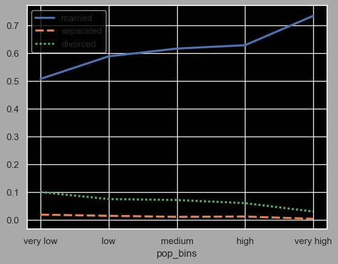

```python
pop_bin_married=df.groupby(by='pop_bins')[['married','separated','divorced']].mean()
sns.lineplot(pop_bin_married,
             linewidth=2.5
             )
```

## Question 9

### Please detail your observations for rent as a percentage of income at an overall level, and for different states.

```python
rent_state_mean = df.groupby(by='state')['rent_mean'].agg(["mean"])
income_state_mean=df.groupby(by='state')['family_mean'].agg(["mean"])
```

```python
rent_perc_of_income=rent_state_mean['mean']/income_state_mean['mean']*100
rent_perc_of_income.head()
```

```
state
Alabama       1.172225
Alaska        1.294831
Arizona       1.486834
Arkansas      1.115344
California    1.672457
Name: mean, dtype: float64
```

```python
rent_perc_of_income=rent_state_mean['mean']/income_state_mean['mean']*100
rent_perc_of_income.head()
```

```
state
Alabama       1.172225
Alaska        1.294831
Arizona       1.486834
Arkansas      1.115344
California    1.672457
Name: mean, dtype: float64
```

```python
sum(df['rent_mean']) / sum(df['family_mean'])
```

```
0.01335408695373265
```

## Question 10

### Perform correlation analysis for all the relevant variables by creating a heatmap. Describe your findings.

```python
px.imshow(df.select_dtypes('number').corr(),
          height = 1000,
          width = 1000,
          template = 'plotly_dark')
```

```python
px.imshow(df[['hc_mortgage_mean', 'aland', 'pop', 'rent_mean', 'hi_mean', 'hc_mean', 'family_mean', 'hs_degree', 'debt', 'home_equity']].corr(),
          text_auto = True,
          template = 'plotly_dark',
          height = 800,
          width = 900)
```

# Building Model

## Data Pre-processing:

#### LabelEncoding

```python
le = LabelEncoder()
```

```python
# Fitting the Label Encoder
df['type'] = le.fit_transform(df['type'])
```

## Question 11

### The economic multivariate data has a significant number of measured variables. The goal is to find where the measured variables depend on a number of smaller unobserved common factors or latent variables.

```python
# Splitting the train test data back
train = df[df['split'] == 'Train']
test = df[df['split'] == 'Test']
```

```python
train.head()
```

| uid | countyid | stateid | state | state_ab | city | place | type | primary | zip_code | area_code | lat | lng | aland | awater | pop | male_pop | female_pop | rent_mean | rent_median | rent_stdev | rent_sample_weight | rent_samples | rent_gt_10 | rent_gt_15 | rent_gt_20 | rent_gt_25 | rent_gt_30 | rent_gt_35 | rent_gt_40 | … |
| --- | --- | --- | --- | --- | --- | --- | --- | --- | --- | --- | --- | --- | --- | --- | --- | --- | --- | --- | --- | --- | --- | --- | --- | --- | --- | --- | --- | --- | --- | --- |
| 220342 | 20 | 2 | Alaska | AK | Eagle River | Anchorage | 2 | tract | 99577 | 907 | 61.174250 | -149.284329 | 509234898.0 | 1859309 | 3727 | 1780 | 1947 | 2347.69441 | 2351.0 | 382.73576 | 4.32064 | 44.0 | 0.79545 | 0.56818 | 0.56818 | 0.45455 | 0.20455 | 0.20455 | 0.20455 | … |
| 220345 | 20 | 2 | Alaska | AK | Anchorage | Point Mackenzie | 2 | tract | 99501 | 907 | 61.229560 | -149.893037 | 2371512.0 | 9966854 | 1941 | 892 | 1049 | 943.79086 | 914.0 | 308.34101 | 396.51652 | 720.0 | 0.97046 | 0.81435 | 0.67651 | 0.58509 | 0.39381 | 0.32208 | 0.27286 | … |
| 220347 | 20 | 2 | Alaska | AK | Anchorage | Anchorage | 2 | tract | 99504 | 907 | 61.217082 | -149.767214 | 1979230.0 | 0 | 5981 | 3076 | 2905 | 1372.84472 | 1222.0 | 541.82102 | 251.53249 | 878.0 | 0.97836 | 0.90319 | 0.80068 | 0.66856 | 0.45900 | 0.34738 | 0.24829 | … |
| 220348 | 20 | 2 | Alaska | AK | Anchorage | Anchorage | 2 | tract | 99504 | 907 | 61.217507 | -149.744426 | 2089774.0 | 0 | 5476 | 2916 | 2560 | 1351.27532 | 1353.0 | 416.08723 | 259.25649 | 963.0 | 0.97701 | 0.96343 | 0.80460 | 0.64054 | 0.51515 | 0.35319 | 0.19749 | … |
| 220349 | 20 | 2 | Alaska | AK | Anchorage | Anchorage | 2 | tract | 99504 | 907 | 61.223372 | -149.723327 | 2936374.0 | 0 | 5893 | 3037 | 2856 | 1022.91322 | 1076.0 | 504.56448 | 529.85586 | 1081.0 | 0.97040 | 0.90564 | 0.90564 | 0.77058 | 0.64477 | 0.48104 | 0.35338 | … |

```python
test.head()
```

| uid | countyid | stateid | state | state_ab | city | place | type | primary | zip_code | area_code | lat | lng | aland | awater | pop | male_pop | female_pop | rent_mean | rent_median | rent_stdev | rent_sample_weight | rent_samples | rent_gt_10 | rent_gt_15 | rent_gt_20 | rent_gt_25 | rent_gt_30 | rent_gt_35 | rent_gt_40 | … |
| --- | --- | --- | --- | --- | --- | --- | --- | --- | --- | --- | --- | --- | --- | --- | --- | --- | --- | --- | --- | --- | --- | --- | --- | --- | --- | --- | --- | --- | --- | --- |
| 220336 | 16 | 2 | Alaska | AK | Unalaska | Unalaska City | 2 | tract | 99685 | 907 | 53.621091 | -166.770979 | 2.823180e+09 | 3101986247 | 4619 | 2725 | 1894 | 1366.24657 | 1405.0 | 650.16380 | 131.50967 | 372.0 | 0.85676 | 0.65676 | 0.47838 | 0.35405 | 0.28108 | 0.21081 | 0.15135 | … |
| 220343 | 20 | 2 | Alaska | AK | Jber | Anchorage | 2 | tract | 99505 | 907 | 61.284745 | -149.653973 | 2.705930e+08 | 66534601 | 8736 | 5166 | 3570 | 2071.30766 | 2089.0 | 442.89099 | 195.07816 | 1749.0 | 0.99469 | 0.97403 | 0.92680 | 0.89020 | 0.73022 | 0.62574 | 0.54368 | … |
| 220352 | 20 | 2 | Alaska | AK | Anchorage | Point Mackenzie | 2 | tract | 99508 | 907 | 61.215067 | -149.836271 | 4.467475e+06 | 0 | 5501 | 3139 | 2362 | 884.61089 | 924.0 | 365.64048 | 564.66795 | 1003.0 | 0.91242 | 0.77291 | 0.64460 | 0.52953 | 0.46130 | 0.37882 | 0.30346 | … |
| 220355 | 20 | 2 | Alaska | AK | Anchorage | Point Mackenzie | 2 | tract | 99501 | 907 | 61.217709 | -149.891261 | 1.196917e+06 | 0 | 924 | 592 | 332 | 852.18031 | 891.0 | 340.09777 | 197.80405 | 327.0 | 0.94154 | 0.91385 | 0.73538 | 0.66462 | 0.61538 | 0.41538 | 0.28615 | … |
| 220364 | 20 | 2 | Alaska | AK | Anchorage | Anchorage | 2 | tract | 99504 | 907 | 61.202363 | -149.733801 | 2.434086e+06 | 0 | 6036 | 3308 | 2728 | 1481.88879 | 1385.0 | 497.27352 | 106.84403 | 477.0 | 0.91405 | 0.76730 | 0.61635 | 0.54298 | 0.29140 | 0.17400 | 0.15514 | … |

- Each variable is assumed to be dependent upon a linear combination of the common factors, and the coefficients are known as loadings. Each measured variable also includes a component due to independent random variability, known as “specific variance” because it is specific to one variable. Obtain the common factors and then plot the loadings. Use factor analysis to find latent variables in our dataset and gain insight into the linear relationships in the data.

##### Following are the list of latent variables:

```
        * Highschool graduation rates

        * Median population age

        * Second mortgage statistics

        * Percent own

        * Bad debt expense
```

```python
fa = FactorAnalyzer(n_factors=5)
fa.fit_transform(train.select_dtypes(exclude= ('object','category')))
fa_results = fa.loadings_
```

```python
fa_df = pd.DataFrame(fa_results)
fa_df.set_index(train.select_dtypes('number').columns, inplace= True)
fa_df.where(fa_df >=0.5)
```

|  | 0 | 1 | 2 | 3 | 4 |
| --- | --- | --- | --- | --- | --- |
| countyid | NaN | NaN | NaN | NaN | NaN |
| stateid | NaN | NaN | NaN | NaN | NaN |
| type | NaN | NaN | NaN | NaN | NaN |
| zip_code | NaN | NaN | NaN | NaN | NaN |
| area_code | NaN | NaN | NaN | NaN | NaN |
| lat | NaN | NaN | NaN | NaN | NaN |
| lng | NaN | NaN | NaN | NaN | NaN |
| aland | NaN | NaN | NaN | NaN | NaN |
| awater | NaN | NaN | NaN | NaN | NaN |
| pop | NaN | 0.961767 | NaN | NaN | NaN |
| male_pop | NaN | 0.926051 | NaN | NaN | NaN |
| female_pop | NaN | 0.954539 | NaN | NaN | NaN |
| rent_mean | 0.756421 | NaN | NaN | NaN | NaN |
| rent_median | 0.704784 | NaN | NaN | NaN | NaN |
| rent_stdev | 0.704324 | NaN | NaN | NaN | NaN |
| rent_sample_weight | NaN | NaN | NaN | NaN | NaN |
| rent_samples | NaN | NaN | NaN | NaN | NaN |
| rent_gt_10 | NaN | NaN | NaN | NaN | NaN |
| rent_gt_15 | NaN | NaN | NaN | 0.659146 | NaN |
| rent_gt_20 | NaN | NaN | NaN | 0.816860 | NaN |
| rent_gt_25 | NaN | NaN | NaN | 0.905071 | NaN |
| rent_gt_30 | NaN | NaN | NaN | 0.933571 | NaN |
| rent_gt_35 | NaN | NaN | NaN | 0.913893 | NaN |
| rent_gt_40 | NaN | NaN | NaN | 0.869300 | NaN |
| rent_gt_50 | NaN | NaN | NaN | 0.762257 | NaN |
| universe_samples | NaN | NaN | NaN | NaN | NaN |
| used_samples | NaN | NaN | NaN | NaN | NaN |
| hi_mean | 0.774085 | NaN | NaN | NaN | NaN |
| hi_median | 0.697474 | NaN | NaN | NaN | NaN |
| hi_stdev | 0.859444 | NaN | NaN | NaN | NaN |
| hi_sample_weight | NaN | 0.847529 | NaN | NaN | NaN |
| hi_samples | NaN | 0.958821 | NaN | NaN | NaN |
| family_mean | 0.823911 | NaN | NaN | NaN | NaN |
| family_median | 0.786580 | NaN | NaN | NaN | NaN |
| family_stdev | 0.814037 | NaN | NaN | NaN | NaN |
| family_sample_weight | NaN | 0.859784 | NaN | NaN | NaN |
| family_samples | NaN | 0.935016 | NaN | NaN | NaN |
| hc_mortgage_mean | 0.974647 | NaN | NaN | NaN | NaN |
| hc_mortgage_median | 0.954544 | NaN | NaN | NaN | NaN |
| hc_mortgage_stdev | 0.818570 | NaN | NaN | NaN | NaN |
| hc_mortgage_sample_weight | NaN | 0.718380 | NaN | NaN | NaN |
| hc_mortgage_samples | NaN | 0.730404 | NaN | NaN | NaN |
| hc_mean | 0.907873 | NaN | NaN | NaN | NaN |
| hc_median | 0.870011 | NaN | NaN | NaN | NaN |
| hc_stdev | 0.760412 | NaN | NaN | NaN | NaN |
| hc_samples | NaN | 0.628482 | 0.595341 | NaN | NaN |
| hc_sample_weight | NaN | 0.575236 | 0.563933 | NaN | NaN |
| home_equity_second_mortgage | NaN | NaN | NaN | NaN | NaN |
| second_mortgage | NaN | NaN | NaN | NaN | NaN |
| home_equity | NaN | NaN | NaN | NaN | NaN |
| debt | NaN | NaN | NaN | NaN | NaN |
| second_mortgage_cdf | NaN | NaN | NaN | NaN | 0.626438 |
| home_equity_cdf | NaN | NaN | NaN | NaN | 0.589429 |
| debt_cdf | NaN | NaN | NaN | NaN | 0.717007 |
| hs_degree | NaN | NaN | NaN | NaN | NaN |
| hs_degree_male | NaN | NaN | NaN | NaN | NaN |
| hs_degree_female | NaN | NaN | NaN | NaN | NaN |
| male_age_mean | NaN | NaN | 0.734432 | NaN | NaN |
| male_age_median | NaN | NaN | 0.767031 | NaN | NaN |
| male_age_stdev | NaN | NaN | 0.563811 | NaN | NaN |
| male_age_sample_weight | NaN | 0.840713 | NaN | NaN | NaN |
| male_age_samples | NaN | 0.925881 | NaN | NaN | NaN |
| female_age_mean | NaN | NaN | 0.720388 | NaN | NaN |
| female_age_median | NaN | NaN | 0.791343 | NaN | NaN |
| female_age_stdev | NaN | NaN | NaN | NaN | NaN |
| female_age_sample_weight | NaN | 0.879196 | NaN | NaN | NaN |
| female_age_samples | NaN | 0.954892 | NaN | NaN | NaN |
| pct_own | NaN | NaN | 0.837123 | NaN | NaN |
| married | NaN | NaN | 0.577636 | NaN | NaN |
| married_snp | NaN | NaN | NaN | NaN | NaN |
| separated | NaN | NaN | NaN | NaN | NaN |
| divorced | NaN | NaN | NaN | NaN | NaN |
| bad_debt | NaN | NaN | NaN | NaN | NaN |
| good_debt | NaN | NaN | NaN | NaN | NaN |
| population_density | NaN | NaN | NaN | NaN | NaN |
| median_age | NaN | NaN | 0.821364 | NaN | NaN |

### Data Modeling :

#### Build a linear Regression model to predict the total monthly expenditure for home mortgages loan.

```python
feature_cols=['countyid', 'stateid', 'zip_code', 'type', 'pop', 'family_mean', 'second_mortgage', 'home_equity', 'debt','hs_degree', 'pct_own',  'married', 'separated', 'divorced']
```

```python
X_train = train[feature_cols]
y_train = train['hc_mortgage_mean']
```

```python
X_test = test[feature_cols]
y_test = test['hc_mortgage_mean']
```

```python
sc = StandardScaler()
X_train = sc.fit_transform(X_train)
X_test = sc.fit_transform(X_test)
```

- a) Run a model at a Nation level. If the accuracy levels and R square are not satisfactory proceed to below step.

```python
lr = LinearRegression()
lr.fit(X_train, y_train)
```

```
LinearRegression()
```

```python
y_pred= lr.predict(X_test)
```

```python
r2_score_nation = r2_score(y_test, y_pred)

print('\n\n>>> R2 Score :')
print(r2_score_nation)
```

```
>>> R2 Score :
0.7293996111231789
```

```python
# Uncomment the line Below to run the State level Model
# r2_score_nation = 0
```

- Storing the Names of the States in dictionary

```python
dict_state = {}
for i in train['stateid'].unique():
    dict_state[i] = df['state'].where(df['stateid']==i).unique()[1]
dict_state[2] = 'Alaska'
print(dict_state)
```

```
{2: 'Alaska', 1: 'Alabama', 5: 'Arkansas', 4: 'Arizona', 6: 'California', 8: 'Colorado', 9: 'Connecticut', 11: 'District of Columbia', 10: 'Delaware', 12: 'Florida', 13: 'Georgia', 15: 'Hawaii', 19: 'Iowa', 16: 'Idaho', 17: 'Illinois', 18: 'Indiana', 20: 'Kansas', 21: 'Kentucky', 22: 'Louisiana', 25…
```

### State Level Model

- Will run if the accuracy of the nation level model comes out to be below 0.6

```python
if r2_score_nation < 0.60:
    for i in train['stateid'].unique():
        print(">>>State ID-",i)

        X_train_nation = train[train['stateid'] == i][feature_cols]
        y_train_nation = train[train['stateid'] == i]['hc_mortgage_mean']

        X_test_nation = test[test['stateid'] == i][feature_cols]
        y_test_nation = test[test['stateid'] == i]['hc_mortgage_mean']


        lr.fit(X_train_nation,y_train_nation)
        y_pred_nation = lr.predict(X_test_nation)

        print(f">>>Overall R2 score of linear regression model for state, {dict_state[i]} : {r2_score(y_test_nation,y_pred_nation)}")
        print('*'*70)
```

[output not shown]

[output cut: 14 more lines]

[output not shown]

[output not shown]

```python
fig_final = px.histogram(data_frame = y_pred,
                         template = 'plotly_dark',
                         title = '<b>Predicted Values Distribution</b>')
fig_final.update_traces(showlegend = False)
fig_final.show()
```

# Thank You for viewing the Real Model Created by Aditya Raj